# USP654 Lab 5: Working with categorical variables

Liming Wang

10/23/2017

## Identify Categorical Variables

What are the categorical variables in `mtcars` and California TOD dataset?

```r
require(tidyverse)
mtcars %>% head
```

```
##                    mpg cyl disp  hp drat    wt  qsec vs am gear carb
## Mazda RX4         21.0   6  160 110 3.90 2.620 16.46  0  1    4    4
## Mazda RX4 Wag     21.0   6  160 110 3.90 2.875 17.02  0  1    4    4
## Datsun 710        22.8   4  108  93 3.85 2.320 18.61  1  1    4    1
## Hornet 4 Drive    21.4   6  258 110 3.08 3.215 19.44  1  0    3    1
## Hornet Sportabout 18.7   8  360 175 3.15 3.440 17.02  0  0    3    2
## Valiant           18.1   6  225 105 2.76 3.460 20.22  1  0    3    1
```

```r
?mtcars
```

```r
californiatod <- read_csv("californiatod.csv")
californiatod %>% head
```

```
## # A tibble: 6 x 6
##                                    name   region transit density houseval               railtype
##                                   <chr>    <chr>   <dbl>   <dbl>    <dbl>                  <chr>
## 1 Archstone Barrington Hills Apartments Bay Area  0.4000    3.36 192593.3 Heavy or commuter rail
## 2                  Archstone Mission Va       SD  0.1077    2.18 203054.6             Light rail
## 3                        Atherton Place Bay Area  0.5000    5.21 217671.5 Heavy or commuter rail
## 4                   Bellamar Apartments       LA  0.3178   10.05 117255.9             Light rail
## 5                        Coggins Square Bay Area  0.5278    4.68 270554.7 Heavy or commuter rail
## 6                       Del Norte Place Bay Area  0.6429    4.91 229335.6 Heavy or commuter rail
```

## Descriptive Stats

For categorical variables, the descriptive statistics and visualization we use is different from numeric variables. For numeric variables, we calculate their mean, standard deviation, median and use histograms and scatter plots to visualize them. For categorical variables, we examine the frequency by categories and use bar chart for visualization.

```r
californiatod %>%
  group_by(region) %>%
  summarize(n=n()) %>%
  mutate(percent=100*n/sum(n))
```

```
## # A tibble: 4 x 3
##       region     n   percent
##        <chr> <int>     <dbl>
## 1   Bay Area    13 50.000000
## 2         LA     6 23.076923
## 3 Sacramento     2  7.692308
## 4         SD     5 19.230769
```

It is common to code a categorical variable with two categories as dummy variable, using 0 and 1 to code either category. For example, sex, auto vs manual transimission, V vs Straight engine. Compare these two ways of doing descriptive stats for `vs` (V vs S engine) and `am` (auto vs manual):

1. mean & sd

```r
mtcars %>%
  summarize(am_mean=mean(am),
            am_sd=sd(am))
```

```
##   am_mean     am_sd
## 1 0.40625 0.4989909
```

2. Frequencies by categories

```r
mtcars %>%
  group_by(am) %>%
  tally
```

```
## # A tibble: 2 x 2
##      am     n
##   <dbl> <int>
## 1     0    19
## 2     1    13
```

```r
# tally is equivalent to summarize(n=n())
```

## Recode Categorical Variables

In many cases, it makes sense to recode categorical variables:

1. From numeric coding (e.g. `am` and `vs`) to more meaningful categorical coding (factor in R, nomial or ordinal variable in SPSS)

```r
(
mtcars_recoded <- mtcars %>%
  mutate(am=factor(am, labels = c(`0`="automatic", `1`="manual")),
         vs=factor(vs, labels = c(`0`="V engine", `1`="S engine")))
)
```

```
##     mpg cyl  disp  hp drat    wt  qsec       vs        am gear carb
## 1  21.0   6 160.0 110 3.90 2.620 16.46 V engine    manual    4    4
## 2  21.0   6 160.0 110 3.90 2.875 17.02 V engine    manual    4    4
## 3  22.8   4 108.0  93 3.85 2.320 18.61 S engine    manual    4    1
## 4  21.4   6 258.0 110 3.08 3.215 19.44 S engine automatic    3    1
## 5  18.7   8 360.0 175 3.15 3.440 17.02 V engine automatic    3    2
## 6  18.1   6 225.0 105 2.76 3.460 20.22 S engine automatic    3    1
## 7  14.3   8 360.0 245 3.21 3.570 15.84 V engine automatic    3    4
## 8  24.4   4 146.7  62 3.69 3.190 20.00 S engine automatic    4    2
## 9  22.8   4 140.8  95 3.92 3.150 22.90 S engine automatic    4    2
## 10 19.2   6 167.6 123 3.92 3.440 18.30 S engine automatic    4    4
## 11 17.8   6 167.6 123 3.92 3.440 18.90 S engine automatic    4    4
## 12 16.4   8 275.8 180 3.07 4.070 17.40 V engine automatic    3    3
## 13 17.3   8 275.8 180 3.07 3.730 17.60 V engine automatic    3    3
## 14 15.2   8 275.8 180 3.07 3.780 18.00 V engine automatic    3    3
```

[output cut: 18 more lines]

```r
# Now repeat the frequencies
mtcars_recoded %>%
  group_by(am) %>%
  tally
```

```
## # A tibble: 2 x 2
##          am     n
##      <fctr> <int>
## 1 automatic    19
## 2    manual    13
```

2. Combine or split categories

```r
## Assume we want to combine LA + SD to Southern CA and Bay Area and Sacramento
## as Northern CA
(
californiatod <- californiatod %>%
  mutate(CA=recode(region, "LA"="Southern", "SD"="Southern", "Bay Area"="Northern", "Sacramento"="Northern"))
)
```

```
## # A tibble: 26 x 7
##                                     name   region transit density houseval               railtype       CA
##                                    <chr>    <chr>   <dbl>   <dbl>    <dbl>                  <chr>    <chr>
##  1 Archstone Barrington Hills Apartments Bay Area  0.4000    3.36 192593.3 Heavy or commuter rail Northern
##  2                  Archstone Mission Va       SD  0.1077    2.18 203054.6             Light rail Southern
##  3                        Atherton Place Bay Area  0.5000    5.21 217671.5 Heavy or commuter rail Northern
##  4                   Bellamar Apartments       LA  0.3178   10.05 117255.9             Light rail Southern
##  5                        Coggins Square Bay Area  0.5278    4.68 270554.7 Heavy or commuter rail Northern
##  6                       Del Norte Place Bay Area  0.6429    4.91 229335.6 Heavy or commuter rail Northern
##  7                      Iron Horse Lofts Bay Area  0.6061    4.68 270207.4 Heavy or commuter rail Northern
##  8                    Mercado Apartments       SD  0.0000    3.21 121786.0             Light rail Southern
##  9                         Mission Wells Bay Area  0.1475    3.96 323497.0 Heavy or commuter rail Northern
## 10                  Northpark Apartments Bay Area  0.1738    3.27 667661.0 Heavy or commuter rail Northern
## # ... with 16 more rows
```

```r
## It is generally a good idea to verify your recode afterwards
californiatod %>%
  group_by(region, CA) %>%
  tally
```

```
## # A tibble: 4 x 3
## # Groups:   region [?]
##       region       CA     n
##        <chr>    <chr> <int>
## 1   Bay Area Northern    13
## 2         LA Southern     6
## 3 Sacramento Northern     2
## 4         SD Southern     5
```

```r
## there should be no mis-classification or cross-over
```

## Visualization

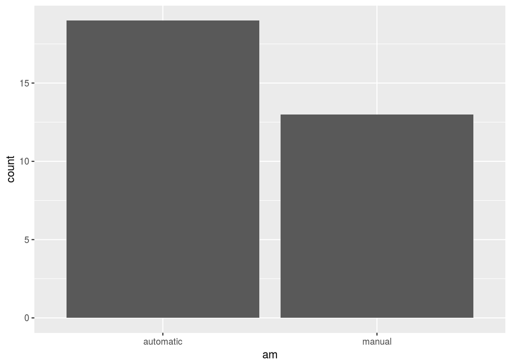

```r
library(ggplot2)
library(scales)
ggplot(mtcars_recoded, aes(x=am)) + geom_bar()
```

Visualize two categorical variables:

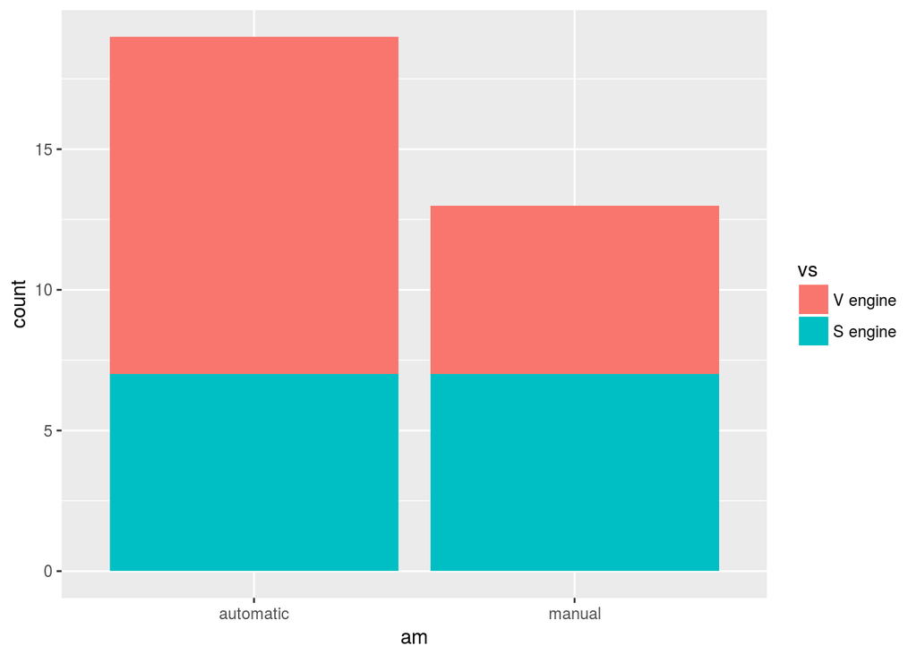

```r
library(ggplot2)
library(scales)
ggplot(mtcars_recoded, aes(x=am, fill=vs)) + geom_bar()
```

## Regression Models with Categorical Indepdent Variables

### Dummy Variables

```r
install.packages("huxtable")
library(huxtable)
huxreg(
  lm(mpg ~ wt + cyl, data=mtcars),
  lm(mpg ~ wt + cyl + am, data=mtcars),
  lm(mpg ~ wt + cyl + vs, data=mtcars)
  )
```

|  | (1) | (2) | (3) |
| --- | --- | --- | --- |
| (Intercept) | 39.686 *** | 39.418 *** | 38.746 *** |
|  | (1.715) | (2.641) | (3.399) |
| wt | -3.191 *** | -3.125 ** | -3.246 *** |
|  | (0.757) | (0.911) | (0.788) |
| cyl | -1.508 *** | -1.510 *** | -1.364 * |
|  | (0.415) | (0.422) | (0.614) |
| am |  | 0.176 |  |
|  |  | (1.304) |  |
| vs |  |  | 0.524 |
|  |  |  | (1.627) |
| N | 32 | 32 | 32 |
| R2 | 0.830 | 0.830 | 0.831 |
| logLik | -74.005 | -73.995 | -73.946 |
| AIC | 156.010 | 157.989 | 157.892 |
| *** p < 0.001; ** p < 0.01; * p < 0.05. |  |  |  |

Compare the above regression results with:

```r
huxreg(
  lm(mpg ~ wt + cyl, data=mtcars_recoded),
  lm(mpg ~ wt + cyl + am, data=mtcars_recoded),
  lm(mpg ~ wt + cyl + vs, data=mtcars_recoded)
  )
```

|  | (1) | (2) | (3) |
| --- | --- | --- | --- |
| (Intercept) | 39.686 *** | 39.418 *** | 38.746 *** |
|  | (1.715) | (2.641) | (3.399) |
| wt | -3.191 *** | -3.125 ** | -3.246 *** |
|  | (0.757) | (0.911) | (0.788) |
| cyl | -1.508 *** | -1.510 *** | -1.364 * |
|  | (0.415) | (0.422) | (0.614) |
| ammanual |  | 0.176 |  |
|  |  | (1.304) |  |
| vsS engine |  |  | 0.524 |
|  |  |  | (1.627) |
| N | 32 | 32 | 32 |
| R2 | 0.830 | 0.830 | 0.831 |
| logLik | -74.005 | -73.995 | -73.946 |
| AIC | 156.010 | 157.989 | 157.892 |
| *** p < 0.001; ** p < 0.01; * p < 0.05. |  |  |  |

### Categorical Variables

R will automatically create dummy variables in regression models when it recoginizes a variable as a categorical variable:

```r
huxreg(
  lm(houseval ~ density + transit, data=californiatod),
  lm(houseval ~ density + transit + railtype, data=californiatod),
  lm(houseval ~ density + transit + region, data=californiatod),
  lm(houseval ~ density + transit + CA, data=californiatod)
  )
```

|  | (1) | (2) | (3) | (4) |
| --- | --- | --- | --- | --- |
| (Intercept) | 302372.952 *** | 501372.179 *** | 452372.464 *** | 393843.122 *** |
|  | (74692.954) | (75244.865) | (79832.719) | (70451.248) |
| density | 1400.738 | -3527.393 | 16901.304 | 14408.559 |
|  | (9551.934) | (7450.777) | (12848.281) | (9197.465) |
| transit | -109641.444 | -439296.953 * | -473692.276 ** | -376981.377 * |
|  | (177081.187) | (158263.007) | (155357.472) | (174589.499) |
| railtypeLight rail |  | -257749.292 *** |  |  |
|  |  | (62863.181) |  |  |
| regionLA |  |  | -310882.199 ** |  |
|  |  |  | (104189.506) |  |
| regionSacramento |  |  | -282136.352 * |  |
|  |  |  | (100731.204) |  |
| regionSD |  |  | -247396.515 ** |  |
|  |  |  | (76529.039) |  |
| CASouthern |  |  |  | -221205.558 ** |
|  |  |  |  | (71923.150) |
| N | 26 | 26 | 26 | 26 |
| R2 | 0.017 | 0.443 | 0.526 | 0.313 |
| logLik | -348.212 | -340.833 | -338.718 | -343.563 |
| AIC | 704.425 | 691.665 | 691.436 | 697.126 |
| *** p < 0.001; ** p < 0.01; * p < 0.05. |  |  |  |  |

### Interaction Terms

```r
huxreg(
  lm(houseval ~ transit, data=californiatod),
  lm(houseval ~ transit * railtype, data=californiatod),
  lm(houseval ~ transit * region, data=californiatod),
  lm(houseval ~ transit * CA, data=californiatod)
  )
```

|  | (1) | (2) | (3) | (4) |
| --- | --- | --- | --- | --- |
| (Intercept) | 309679.650 *** | 489860.254 *** | 563768.233 *** | 470312.732 *** |
|  | (54499.249) | (63396.441) | (65545.336) | (70244.579) |
| transit | -108845.594 | -466553.246 * | -578638.922 ** | -427148.395 * |
|  | (173352.298) | (171068.722) | (162707.892) | (184092.846) |
| railtypeLight rail |  | -285484.331 ** |  |  |
|  |  | (91944.365) |  |  |
| transit:railtypeLight rail |  | 213902.986 |  |  |
|  |  | (446175.602) |  |  |
| regionLA |  |  | -383094.628 ** |  |
|  |  |  | (116975.004) |  |
| regionSacramento |  |  | -631381.373 |  |
|  |  |  | (523238.505) |  |
| regionSD |  |  | -426482.796 ** |  |
|  |  |  | (128973.891) |  |
| transit:regionLA |  |  | 817086.819 |  |
|  |  |  | (461199.051) |  |
| transit:regionSacramento |  |  | 1570778.725 |  |
|  |  |  | (2698121.518) |  |
| transit:regionSD |  |  | 1132780.410 |  |
|  |  |  | (875341.915) |  |
| CASouthern |  |  |  | -303957.765 ** |
|  |  |  |  | (105195.228) |
| transit:CASouthern |  |  |  | 734326.740 |
|  |  |  |  | (456846.386) |
| N | 26 | 26 | 26 | 26 |
| R2 | 0.016 | 0.443 | 0.594 | 0.316 |
| logLik | -348.225 | -340.829 | -336.714 | -343.494 |
| AIC | 702.449 | 691.659 | 691.429 | 696.989 |
| *** p < 0.001; ** p < 0.01; * p < 0.05. |  |  |  |  |

## Tasks

1. Identify the categorical variables in your own dataset
2. Select a few of the categorical variables
   - How is each of them code (dummy, numeric, or character)?
   - Recode the categorical variables that are not properly coded currently
   - Consider combine/recode some of the categories for one of your categorical variables
   - Run regression models including your categorical variables as independent variables; think about how you interpret the results of your regression
   - Test interaction effects between your categorical variables and numeric variables.